# AFC & SEM

Alvaro Rivera

2023-02-22

As you may have seen in the previous steps of our analysis, the model including all variables did not perform as well as expected within the theoretical framework. Therefore, I have chosen to examine three theoretical models based on Cho & Jang’s (2016) article and compare their structures with the observations from my large survey.

```r
library("semPlot")
library("readr")
library("lavaan")
library("readxl")
library("dplyr")
```

SO now I am calling my dataframe and take a look into the variables I will use.

```r
setwd("/home/alrier/Descargas")
datos2 = read_excel("/home/alrier/Descargas/Variables Cho & Yang.xlsx")
datos2 %>% head()
```

| utilitario1 | utilitario2 | utilitario3 | ries_perc1 | ries_perc2 | ries_perc3 | Hedónico1 | Hedónico2 | Hedónico3 | busq_sens1 | busq_sens2 | busq_sens3 | social1 | social2 | social3 | val_social1 | val_social2 | val_social3 | uso_r_sociales1 | uso_r_sociales2 | uso_r_sociales3 | uso_r_sociales4 | uso_r_sociales5 | Int_busq_info1 | Int_busq_info2 | Int_busq_info3 | int_visita1 | int_visita2 | int_visita3 | int_visita4 |
| --- | --- | --- | --- | --- | --- | --- | --- | --- | --- | --- | --- | --- | --- | --- | --- | --- | --- | --- | --- | --- | --- | --- | --- | --- | --- | --- | --- | --- | --- |
| 4 | 5 | 3 | 5 | 5 | 5 | 6 | 5 | 4 | 5 | 5 | 5 | 5 | 6 | 3 | 3 | 3 | 3 | 4 | 4 | 4 | 4 | 5 | 3 | 3 | 6 | 5 | 6 | 3 | 3 |
| 4 | 5 | 3 | 5 | 5 | 5 | 6 | 5 | 4 | 5 | 5 | 5 | 5 | 6 | 3 | 3 | 3 | 3 | 4 | 4 | 4 | 4 | 5 | 3 | 3 | 6 | 5 | 6 | 3 | 3 |
| 4 | 5 | 3 | 5 | 5 | 5 | 6 | 5 | 4 | 5 | 5 | 5 | 5 | 6 | 3 | 3 | 3 | 3 | 4 | 4 | 4 | 4 | 5 | 3 | 3 | 6 | 5 | 6 | 3 | 3 |
| 4 | 5 | 3 | 5 | 5 | 5 | 6 | 5 | 4 | 5 | 5 | 5 | 5 | 6 | 3 | 3 | 3 | 3 | 4 | 4 | 4 | 4 | 5 | 3 | 3 | 6 | 5 | 6 | 3 | 3 |
| 6 | 4 | 4 | 6 | 6 | 6 | 7 | 7 | 7 | 7 | 7 | 7 | 5 | 7 | 7 | 7 | 4 | 4 | 7 | 7 | 5 | 7 | 7 | 7 | 5 | 5 | 1 | 2 | 1 | 1 |
| 5 | 5 | 5 | 6 | 5 | 5 | 5 | 5 | 5 | 5 | 5 | 5 | 5 | 5 | 5 | 5 | 5 | 5 | 5 | 5 | 5 | 5 | 5 | 5 | 5 | 5 | 5 | 5 | 5 | 5 |

Now I will create a slice of my Data frame to choose only the variables that are useful in the study.

```r
datos2 = datos2[1:18]
datos2 %>% head()
```

| utilitario1 | utilitario2 | utilitario3 | ries_perc1 | ries_perc2 | ries_perc3 | Hedónico1 | Hedónico2 | Hedónico3 | busq_sens1 | busq_sens2 | busq_sens3 | social1 | social2 | social3 | val_social1 | val_social2 | val_social3 |
| --- | --- | --- | --- | --- | --- | --- | --- | --- | --- | --- | --- | --- | --- | --- | --- | --- | --- |
| 4 | 5 | 3 | 5 | 5 | 5 | 6 | 5 | 4 | 5 | 5 | 5 | 5 | 6 | 3 | 3 | 3 | 3 |
| 4 | 5 | 3 | 5 | 5 | 5 | 6 | 5 | 4 | 5 | 5 | 5 | 5 | 6 | 3 | 3 | 3 | 3 |
| 4 | 5 | 3 | 5 | 5 | 5 | 6 | 5 | 4 | 5 | 5 | 5 | 5 | 6 | 3 | 3 | 3 | 3 |
| 4 | 5 | 3 | 5 | 5 | 5 | 6 | 5 | 4 | 5 | 5 | 5 | 5 | 6 | 3 | 3 | 3 | 3 |
| 6 | 4 | 4 | 6 | 6 | 6 | 7 | 7 | 7 | 7 | 7 | 7 | 5 | 7 | 7 | 7 | 4 | 4 |
| 5 | 5 | 5 | 6 | 5 | 5 | 5 | 5 | 5 | 5 | 5 | 5 | 5 | 5 | 5 | 5 | 5 | 5 |

Now I will create the first model with all the first group of variables. In this model all the variables are together without ny distinction.

```r
modelo_confir1 <- 'vp =~ utilitario1    + utilitario2   + utilitario3   + ries_perc1    + ries_perc2    + ries_perc3    + Hedónico1 + Hedónico2 + Hedónico3 + busq_sens1    + busq_sens2    + busq_sens3    + social1   + social2   + social3   + val_social1   + val_social2   + val_social3'
```

Now I will proceed to analyse the information and take a look into the summary of the model.

```r
modelo1 <- cfa(modelo_confir1, data = datos2)
summary(modelo1, fit.measures=TRUE, rsq=TRUE)
```

```
## lavaan 0.6-11 ended normally after 34 iterations
##
##   Estimator                                         ML
##   Optimization method                           NLMINB
##   Number of model parameters                        36
##
##   Number of observations                           821
##
## Model Test User Model:
##
##   Test statistic                              5889.638
##   Degrees of freedom                               135
##   P-value (Chi-square)                           0.000
##
## Model Test Baseline Model:
##
##   Test statistic                             13813.124
##   Degrees of freedom                               153
##   P-value                                        0.000
##
## User Model versus Baseline Model:
##
##   Comparative Fit Index (CFI)                    0.579
##   Tucker-Lewis Index (TLI)                       0.523
##
## Loglikelihood and Information Criteria:
##
##   Loglikelihood user model (H0)             -25451.289
##   Loglikelihood unrestricted model (H1)     -22506.470
##
##   Akaike (AIC)                               50974.578
##   Bayesian (BIC)                             51144.157
##   Sample-size adjusted Bayesian (BIC)        51029.835
##
## Root Mean Square Error of Approximation:
##
##   RMSEA                                          0.228
##   90 Percent confidence interval - lower         0.223
##   90 Percent confidence interval - upper         0.233
##   P-value RMSEA <= 0.05                          0.000
```

[output cut: 60 more lines]

```
##     ries_perc1        0.066
##     ries_perc2        0.025
##     ries_perc3        0.034
##     Hedónico1         0.685
##     Hedónico2         0.788
##     Hedónico3         0.526
##     busq_sens1        0.734
##     busq_sens2        0.681
##     busq_sens3        0.556
##     social1           0.566
##     social2           0.605
##     social3           0.596
##     val_social1       0.428
##     val_social2       0.240
##     val_social3       0.264
```

```r
parameterestimates(modelo1, standardized = TRUE)
```

| lhs | op | rhs | est | se | z | pvalue | ci.lower | ci.upper | std.lv | std.all | std.nox |
| --- | --- | --- | --- | --- | --- | --- | --- | --- | --- | --- | --- |
| vp | =~ | utilitario1 | 1.0000000 | 0.00000000 | NA | NA | 1.0000000 | 1.0000000 | 1.3280680 | 0.7148841 | 0.7148841 |
| vp | =~ | utilitario2 | 1.0278110 | 0.05052251 | 20.343626 | 0.000000e+00 | 0.9287887 | 1.1268333 | 1.3650030 | 0.7193485 | 0.7193485 |
| vp | =~ | utilitario3 | 0.9548878 | 0.04821415 | 19.805137 | 0.000000e+00 | 0.8603898 | 1.0493858 | 1.2681560 | 0.7006274 | 0.7006274 |
| vp | =~ | ries_perc1 | 0.3314876 | 0.04587183 | 7.226387 | 4.960476e-13 | 0.2415805 | 0.4213947 | 0.4402381 | 0.2575445 | 0.2575445 |
| vp | =~ | ries_perc2 | 0.2118475 | 0.04740442 | 4.468941 | 7.860790e-06 | 0.1189366 | 0.3047585 | 0.2813479 | 0.1593850 | 0.1593850 |
| vp | =~ | ries_perc3 | 0.2425872 | 0.04711184 | 5.149177 | 2.616317e-07 | 0.1502497 | 0.3349247 | 0.3221723 | 0.1836189 | 0.1836189 |
| vp | =~ | Hedónico1 | 1.1305213 | 0.04815366 | 23.477368 | 0.000000e+00 | 1.0361418 | 1.2249007 | 1.5014092 | 0.8278493 | 0.8278493 |
| vp | =~ | Hedónico2 | 1.2570958 | 0.04986524 | 25.209862 | 0.000000e+00 | 1.1593617 | 1.3548299 | 1.6695088 | 0.8876686 | 0.8876686 |
| vp | =~ | Hedónico3 | 0.8987235 | 0.04382940 | 20.505037 | 0.000000e+00 | 0.8128194 | 0.9846275 | 1.1935659 | 0.7249554 | 0.7249554 |
| vp | =~ | busq_sens1 | 1.1685749 | 0.04804796 | 24.321010 | 0.000000e+00 | 1.0744026 | 1.2627471 | 1.5519470 | 0.8569650 | 0.8569650 |

[output cut: 27 more lines]

As you can see the fit indexes are not the best and the relation between variables are not the best too.

I will try the next model.

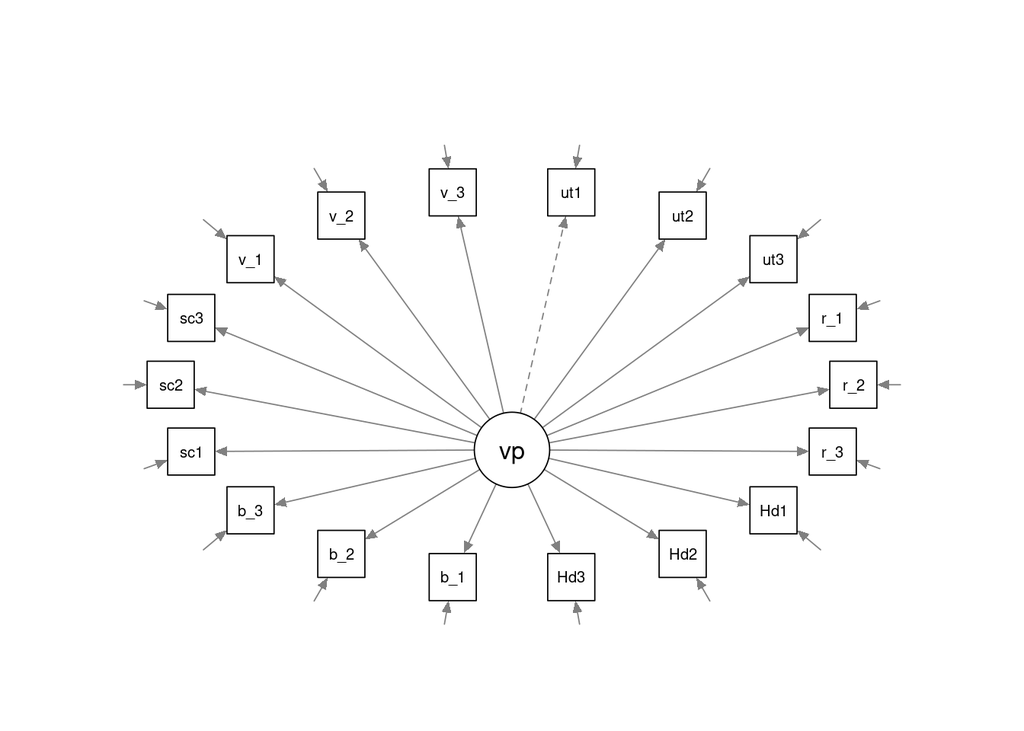

```r
semPaths(modelo1, what = "paths", layout = "circle", title = TRUE, style = "LISREL")
```

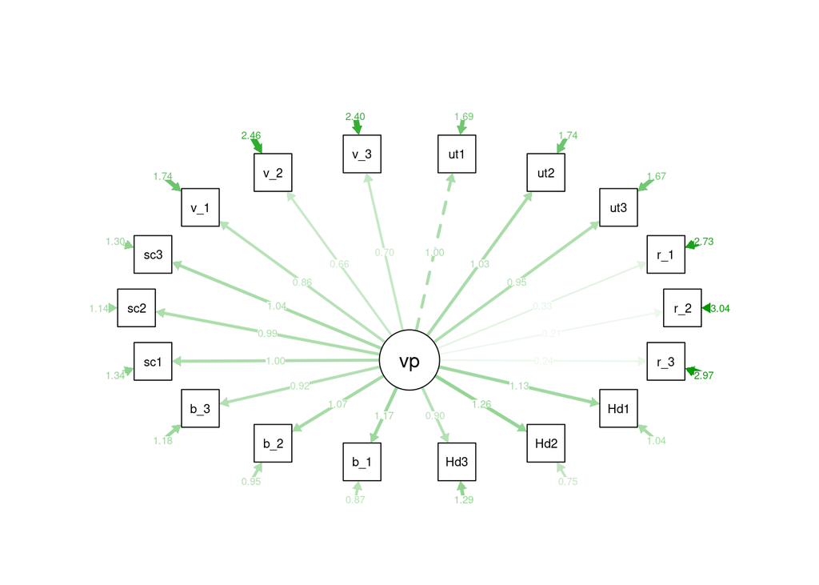

```r
semPaths(modelo1, what = "est", layout = "circle", title = TRUE, style = "LISREL")
```

MODEL 2

This is a model with 2 latent variables correlated, so, lets take a look into the model and see if the variables adjust or not with it.

```r
modelo_confir2 <- 'V.util =~ utilitario1    + utilitario2   + utilitario3   + ries_perc1    + ries_perc2    + ries_perc3
V.espx =~ Hedónico1 + Hedónico2 + Hedónico3 + busq_sens1    + busq_sens2    + busq_sens3    + social1   + social2   + social3   + val_social1   + val_social2   + val_social3
V.util~~V.espx'
```

```r
modelo2 <- cfa(modelo_confir2, data = datos2)
summary(modelo2, fit.measures=TRUE, rsq=TRUE)
```

```
## lavaan 0.6-11 ended normally after 39 iterations
##
##   Estimator                                         ML
##   Optimization method                           NLMINB
##   Number of model parameters                        37
##
##   Number of observations                           821
##
## Model Test User Model:
##
##   Test statistic                              4351.652
##   Degrees of freedom                               134
##   P-value (Chi-square)                           0.000
##
## Model Test Baseline Model:
##
##   Test statistic                             13813.124
##   Degrees of freedom                               153
##   P-value                                        0.000
##
## User Model versus Baseline Model:
##
##   Comparative Fit Index (CFI)                    0.691
##   Tucker-Lewis Index (TLI)                       0.647
##
## Loglikelihood and Information Criteria:
##
##   Loglikelihood user model (H0)             -24682.296
##   Loglikelihood unrestricted model (H1)     -22506.470
##
##   Akaike (AIC)                               49438.592
##   Bayesian (BIC)                             49612.882
##   Sample-size adjusted Bayesian (BIC)        49495.384
##
## Root Mean Square Error of Approximation:
##
##   RMSEA                                          0.196
##   90 Percent confidence interval - lower         0.191
##   90 Percent confidence interval - upper         0.201
##   P-value RMSEA <= 0.05                          0.000
```

[output cut: 67 more lines]

```
##     ries_perc1        0.016
##     ries_perc2        0.003
##     ries_perc3        0.048
##     Hedónico1         0.679
##     Hedónico2         0.750
##     Hedónico3         0.563
##     busq_sens1        0.757
##     busq_sens2        0.745
##     busq_sens3        0.609
##     social1           0.586
##     social2           0.633
##     social3           0.606
##     val_social1       0.399
##     val_social2       0.207
##     val_social3       0.229
```

It goes a little bit better, the CFI and the RMSEA are a little bit better, however lets tke a look into the next model.

```r
parameterestimates(modelo2, standardized = TRUE)
```

| lhs | op | rhs | est | se | z | pvalue | ci.lower | ci.upper | std.lv | std.all | std.nox |
| --- | --- | --- | --- | --- | --- | --- | --- | --- | --- | --- | --- |
| V.util | =~ | utilitario1 | 1.00000000 | 0.00000000 | NA | NA | 1.00000000 | 1.0000000 | 1.6247217 | 0.87457136 | 0.87457136 |
| V.util | =~ | utilitario2 | 1.12810766 | 0.02552793 | 44.191112 | 0.000000e+00 | 1.07807384 | 1.1781415 | 1.8328610 | 0.96590905 | 0.96590905 |
| V.util | =~ | utilitario3 | 1.04867456 | 0.02495438 | 42.023669 | 0.000000e+00 | 0.99976488 | 1.0975842 | 1.7038043 | 0.94131479 | 0.94131479 |
| V.util | =~ | ries_perc1 | 0.13486252 | 0.03721166 | 3.624201 | 2.898561e-04 | 0.06192902 | 0.2077960 | 0.2191141 | 0.12818518 | 0.12818518 |
| V.util | =~ | ries_perc2 | 0.05858597 | 0.03860711 | 1.517492 | 1.291425e-01 | -0.01708257 | 0.1342545 | 0.0951859 | 0.05392365 | 0.05392365 |
| V.util | =~ | ries_perc3 | 0.23613206 | 0.03777828 | 6.250472 | 4.092147e-10 | 0.16208800 | 0.3101761 | 0.3836489 | 0.21865532 | 0.21865532 |
| V.espx | =~ | Hedónico1 | 1.00000000 | 0.00000000 | NA | NA | 1.00000000 | 1.0000000 | 1.4945171 | 0.82404940 | 0.82404940 |
| V.espx | =~ | Hedónico2 | 1.08979441 | 0.03522032 | 30.942208 | 0.000000e+00 | 1.02076386 | 1.1588250 | 1.6287164 | 0.86598029 | 0.86598029 |
| V.espx | =~ | Hedónico3 | 0.82629955 | 0.03315377 | 24.923243 | 0.000000e+00 | 0.76131935 | 0.8912798 | 1.2349188 | 0.75007253 | 0.75007253 |
| V.espx | =~ | busq_sens1 | 1.05435842 | 0.03381282 | 31.182210 | 0.000000e+00 | 0.98808651 | 1.1206303 | 1.5757567 | 0.87011345 | 0.87011345 |

[output cut: 29 more lines]

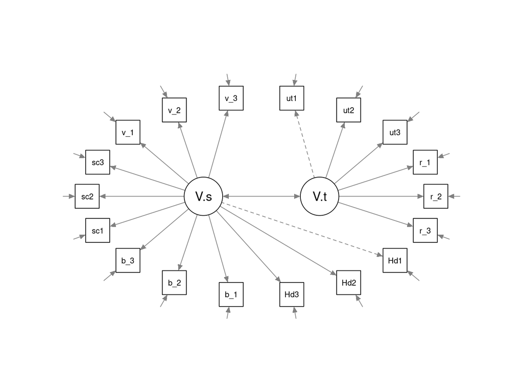

```r
semPaths(modelo2, what = "paths", layout = "circle", title = TRUE, style = "LISREL")
```

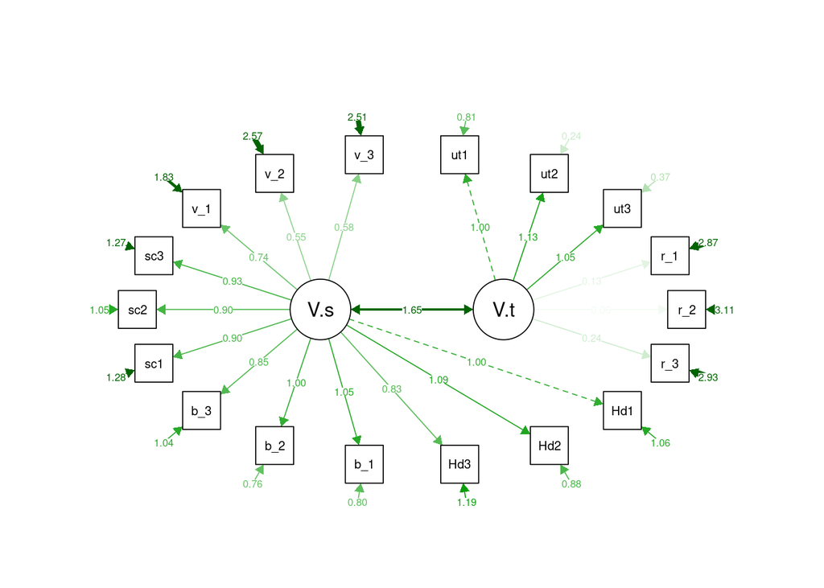

```r
semPaths(modelo2, what = "est", layout = "circle", title = TRUE, style = "LISREL")
```

I really dislike the Hd3, Hd1, b_2, b_1, all the r variables… it makes me think that this model could be improved.

```r
modelo_confir3 <- '
V.util =~ utilitario1   + utilitario2   + utilitario3   +
ries_perc1  + ries_perc2    + ries_perc3
V.espx =~ Hedónico1 + Hedónico2 + Hedónico3 + busq_sens1    +
busq_sens2  + busq_sens3    + social1   + social2   + social3   + val_social1   +
val_social2 + val_social3

V.espx ~~ 0* V.util
'
```

```r
modelo3 <- cfa(modelo_confir3, data = datos2)
summary(modelo3, fit.measures=TRUE, rsq=TRUE)
```

```
## lavaan 0.6-11 ended normally after 49 iterations
##
##   Estimator                                         ML
##   Optimization method                           NLMINB
##   Number of model parameters                        36
##
##   Number of observations                           821
##
## Model Test User Model:
##
##   Test statistic                              4791.903
##   Degrees of freedom                               135
##   P-value (Chi-square)                           0.000
##
## Model Test Baseline Model:
##
##   Test statistic                             13813.124
##   Degrees of freedom                               153
##   P-value                                        0.000
##
## User Model versus Baseline Model:
##
##   Comparative Fit Index (CFI)                    0.659
##   Tucker-Lewis Index (TLI)                       0.614
##
## Loglikelihood and Information Criteria:
##
##   Loglikelihood user model (H0)             -24902.422
##   Loglikelihood unrestricted model (H1)     -22506.470
##
##   Akaike (AIC)                               49876.844
##   Bayesian (BIC)                             50046.423
##   Sample-size adjusted Bayesian (BIC)        49932.100
##
## Root Mean Square Error of Approximation:
##
##   RMSEA                                          0.205
##   90 Percent confidence interval - lower         0.200
##   90 Percent confidence interval - upper         0.210
##   P-value RMSEA <= 0.05                          0.000
```

[output cut: 67 more lines]

```
##     ries_perc1        0.014
##     ries_perc2        0.002
##     ries_perc3        0.047
##     Hedónico1         0.670
##     Hedónico2         0.723
##     Hedónico3         0.575
##     busq_sens1        0.758
##     busq_sens2        0.769
##     busq_sens3        0.630
##     social1           0.590
##     social2           0.641
##     social3           0.605
##     val_social1       0.383
##     val_social2       0.191
##     val_social3       0.211
```

```r
parameterestimates(modelo3, standardized = TRUE)
```

| lhs | op | rhs | est | se | z | pvalue | ci.lower | ci.upper | std.lv | std.all | std.nox |
| --- | --- | --- | --- | --- | --- | --- | --- | --- | --- | --- | --- |
| V.util | =~ | utilitario1 | 1.00000000 | 0.00000000 | NA | NA | 1.00000000 | 1.0000000 | 1.61677502 | 0.87029238 | 0.87029238 |
| V.util | =~ | utilitario2 | 1.13666783 | 0.02617735 | 43.421804 | 0.000000e+00 | 1.08536116 | 1.1879745 | 1.83773615 | 0.96847646 | 0.96847646 |
| V.util | =~ | utilitario3 | 1.05371861 | 0.02544194 | 41.416602 | 0.000000e+00 | 1.00385333 | 1.1035839 | 1.70362594 | 0.94121471 | 0.94121471 |
| V.util | =~ | ries_perc1 | 0.12599469 | 0.03741989 | 3.367051 | 7.597650e-04 | 0.05265306 | 0.1993363 | 0.20370507 | 0.11917011 | 0.11917011 |
| V.util | =~ | ries_perc2 | 0.05110418 | 0.03879966 | 1.317129 | 1.877952e-01 | -0.02494176 | 0.1271501 | 0.08262396 | 0.04680704 | 0.04680704 |
| V.util | =~ | ries_perc3 | 0.23526979 | 0.03797910 | 6.194718 | 5.838943e-10 | 0.16083213 | 0.3097075 | 0.38037833 | 0.21679272 | 0.21679272 |
| V.espx | =~ | Hedónico1 | 1.00000000 | 0.00000000 | NA | NA | 1.00000000 | 1.0000000 | 1.48437296 | 0.81845759 | 0.81845759 |
| V.espx | =~ | Hedónico2 | 1.07727802 | 0.03631384 | 29.665772 | 0.000000e+00 | 1.00610420 | 1.1484518 | 1.59908236 | 0.85022467 | 0.85022467 |
| V.espx | =~ | Hedónico3 | 0.84089475 | 0.03354042 | 25.071087 | 0.000000e+00 | 0.77515674 | 0.9066328 | 1.24820142 | 0.75814099 | 0.75814099 |
| V.espx | =~ | busq_sens1 | 1.06238120 | 0.03449598 | 30.797248 | 0.000000e+00 | 0.99477032 | 1.1299921 | 1.57696992 | 0.87078368 | 0.87078368 |

[output cut: 29 more lines]

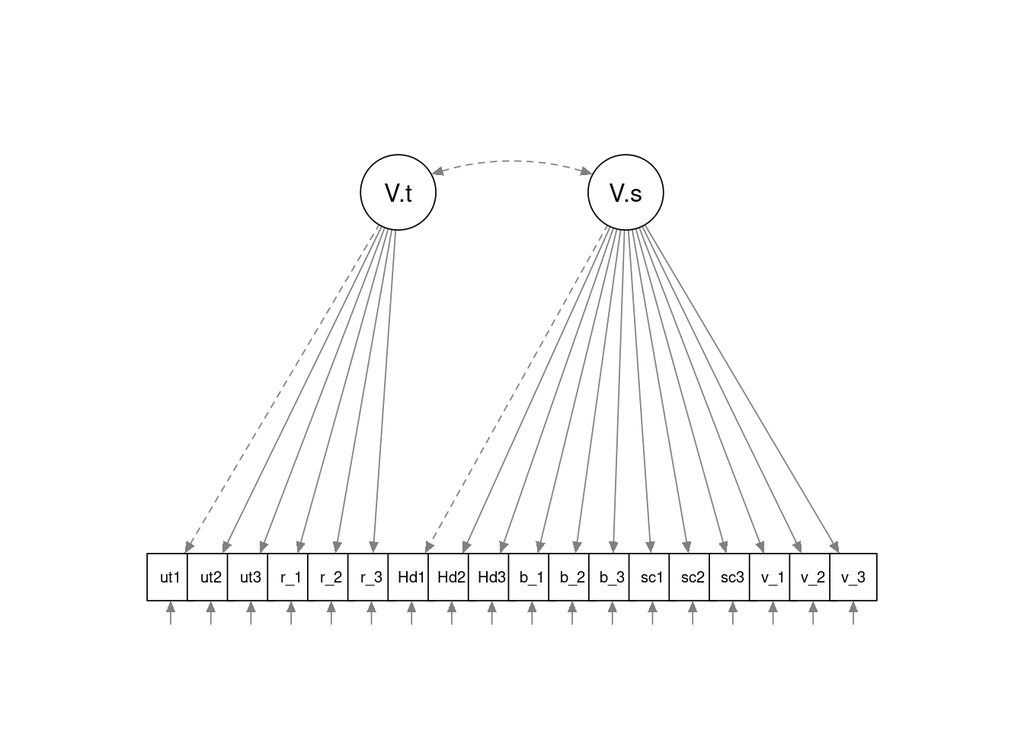

```r
semPaths(modelo3, what = "paths", layout = "tree", title = TRUE, style = "LISREL")
```

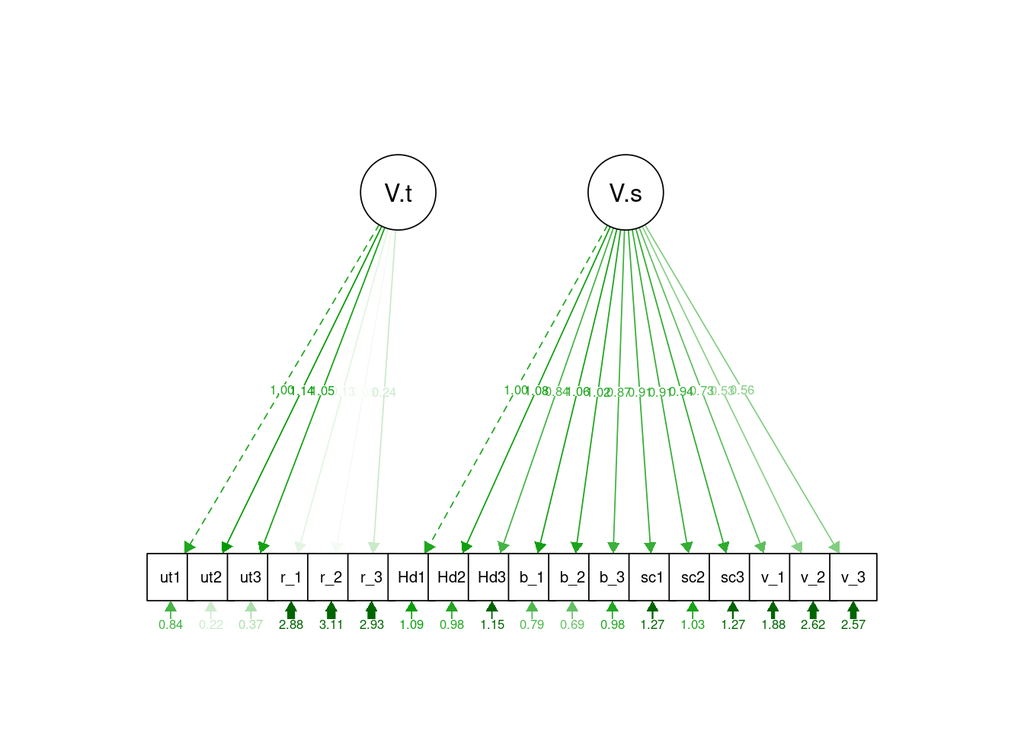

```r
semPaths(modelo3, what = "est", layout = "tree", title = TRUE, style = "LISREL")
```

This last model is not working too, since the errors are extremely high for some variables and the correlation between latent variables and the dimentions are so high in some cases too.

That’s why in the article I published aput this topic, I have created a new model with 4 latent variables.